# Фибоначчи. Исследование

### #Занимательная Математика

Импорт библиотек для IPython

```python
from IPython.display import Image
from IPython.core.display import HTML
InteractiveShell.ast_node_interactivity = "last"
```

```python
Image(url="https://hightech.fm/wp-content/uploads/2019/06/antlia2-collision-2.jpg", width=400)
```

[figure not shown]

Источник: Википедия

> Числа Фибоначчи — элементы числовой последовательности, в которой первые два числа равны либо 1 и 1, либо 0 и 1, а каждое последующее число равно сумме двух предыдущих чисел.

Более формально, последовательность чисел Фибоначчи $ \{F_n\} $ задаётся линейным рекуррентным соотношением:

$ F_0=0,\; F_1=1,\;\;\; F_n={F_{n-1}}+{F_{n-2}},\;\;\; n \geq2,\; n \in Z $

Теперь подключу библиотеки для моей работы

```python
import numpy as np
import sympy as sp
import pandas as pd
import random as r
import time
import matplotlib.pyplot as plt
import ipyturtle as turtle

from scipy.ndimage.filters import gaussian_filter1d
from scipy.signal import savgol_filter
```

Сперва, мы рассмотрим некоторые алгоритмы и сравним их, а затем перейдём к творческой и занимательной части

Например, сначала я реализовал алгоритм нахождения числа Фибоначчи рекурсией.  
На вход мы подаём порядковый номер во всей последовательности, а на выход получаем само число Фибоначчи.  
И так я буду стараться делать и дальше.

```python
def RecursionFibonacci(index):
    if index==1:
        return 0
    elif index==2:
        return 1
    else:
        return RecursionFibonacci(index-1)+RecursionFibonacci(index-2)
```

```python
#Находим девятое число Фибоначчи
RecursionFibonacci(9)
```

```
21
```

Вот, вроде быстро вышло, но давайте замерим скорость выполнения данной функции

```python
%time RecursionFibonacci(9)
;
```

```
CPU times: user 14 µs, sys: 1 µs, total: 15 µs
Wall time: 17.4 µs
```

```
''
```

Ну....так не пойдёт.  
Измерять скорость лучше на нескольких выполнениях функции.  
То есть сделаем итерацию много раз

```python
%timeit RecursionFibonacci(9)
```

```
8.9 µs ± 19.2 ns per loop (mean ± std. dev. of 7 runs, 100000 loops each)
```

И это мы проверяем, когда находим девятое число!  
Попробуем находить рандомные. Тогда замерим среднее выполнение именно этих чисел

```python
#%timeit RecursionFibonacci(r.randint(1,50))
```

Да ну его! И не запускайте. Прошло больше 3 минут. Давай-те понизим значение

```python
%timeit RecursionFibonacci(r.randint(1,5))
```

```
1.83 µs ± 1.82 ns per loop (mean ± std. dev. of 7 runs, 1000000 loops each)
```

Довольно интересно получается. Примерно 15 секунд это вычислялось 😀

Попробую замерить теперь по-своему. И заодно проверим как изменяется скорость выполнения этой рекурсии в зависимости от числа, которое мы подадим на вход.

```python
#Создаём массив, в котором будем хранить тайминги
s = np.array([])

#Сделаем итерации такие, что будем подавать на вход индексы от 15 до 50
for i in range(15,40):

    #Включаем "таймер"
    start_time = time.time()

    RecursionFibonacci(i)

    #Стоп таймер (время зафиксируется как только закончится выполнения рекурсии)
    end_time = (time.time() - start_time)
    s=np.append(s,end_time)
    #print("--- %s seconds ---" % end_time)
```

Вот такие будут значения!

| Номер итерации | Время |
| --- | --- |
| 10 | 0.01 секунд |
| 11 | 0.02 секунд |
| 12 | 0.03 секунд |
| 13 | 0.05 секунд |
| 14 | 0.08 секунд |
| 15 | 0.13 секунд |
| 16 | 0.22 секунд |
| 17 | 0.36 секунд |
| 18 | 0.58 секунд |
| 19 | 0.9 секунд |
| 20 | 1.5 секунд |
| 21 | 2.4 секунд |
| 22 | 4.0 секунд |
| 23 | 6.4 секунд |
| 24 | 10 секунд |
| 25 | 16.97 секунд |

```python
def drawPlot(ss,title="Скорости",y="Секунд",x="Номер итерации"):
    fig,ax=plt.subplots(figsize=(6,6))
    ax.set_facecolor("#F2F2F2")
    ax.grid()
    ax.set_title(title)
    ax.set_ylabel(y)
    ax.set_xlabel(x)
    ax.plot(ss)
```

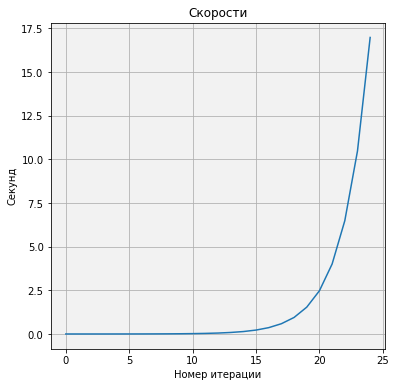

```python
drawPlot(s)
```

Данный график показывает, как именно будет идти рекурсия в секундах в зависимости от числа  
Причём, можно заметить, что график напоминает функцию: $ {-30}\over{x-50} $

Хорошо, а давайте этой же рекурсией будем создавать именно последовательность.  
Затем, замерим время выполнения.

```python
#Массив с числами Фибоначчи
FibArray=np.array([0,1])

def RecursionFibonacciSequence(index):
    global FibArray

    if index<=len(FibArray):
        return FibArray[index-1]
    else:
        fib=RecursionFibonacciSequence(index-1)+RecursionFibonacciSequence(index-2)
        FibArray=np.append(FibArray,fib)
        return fib

RecursionFibonacciSequence(92)
;
#Итак, вот первые 92 числа Фибоначчи
#FibArray
```

```
''
```

```python
%time RecursionFibonacciSequence(92)
;
```

```
CPU times: user 6 µs, sys: 1e+03 ns, total: 7 µs
Wall time: 9.06 µs
```

```
''
```

```python
%timeit RecursionFibonacciSequence(92)
;
```

```
310 ns ± 0.429 ns per loop (mean ± std. dev. of 7 runs, 1000000 loops each)
```

```
''
```

Что-ж...Давайте глянем на другой алгоритм

```python
#Применим итерационный метод для оптимизации места
def IterationFibonacci(index):
    a=0
    b=1
    if index == 0:
        return a
    elif index == 1:
        return b
    else:
        for i in range(2,index):
            c=a+b
            a=b
            b=c
        return b

IterationFibonacci(90000) #Довольно быстро нашло
;
```

```
''
```

Теперь замерим вычисления и построим график.

Для более сглаженного графика пропустим его через фильтр Гаусса

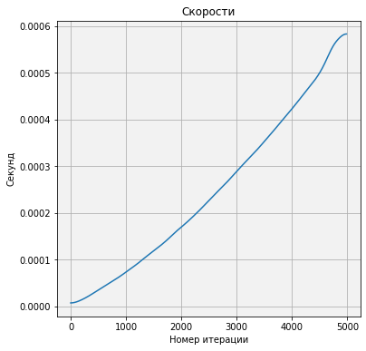

```python
s2 = np.array([])
for i in range(15,5000):
    start_time = time.time()
    IterationFibonacci(i)
    end_time = (time.time() - start_time)
    s2=np.append(s2,end_time)
    #print("--- %s seconds ---" % end_time)

s2 = gaussian_filter1d(s2, sigma=100)
drawPlot(s2)
```

```python
%time IterationFibonacci(50000)
;
```

```
CPU times: user 32.4 ms, sys: 10 µs, total: 32.4 ms
Wall time: 31.8 ms
```

```
''
```

```python
%timeit IterationFibonacci(50000)
;
```

```
30.1 ms ± 24.9 µs per loop (mean ± std. dev. of 7 runs, 10 loops each)
```

```
''
```

Даже на таких числах итерация работает гораздо быстрее. Да и график стал более линейным.

Окей. А если сделать алгоритм, используя while?

```python
def whileFibonacci(index):
    a=0
    b=1
    i=0
    while i<index-2:
        c=a+b
        a=b
        b=c
        i+=1

    return b

whileFibonacci(90000)
;
```

```
''
```

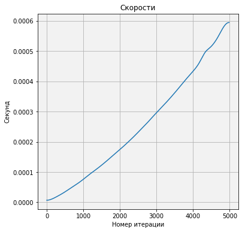

```python
s3 = np.array([])
for i in range(15,5000):
    start_time = time.time()
    IterationFibonacci(i)
    end_time = (time.time() - start_time)
    s3=np.append(s3,end_time)
    #print("--- %s seconds ---" % end_time)

s3 = gaussian_filter1d(s3, sigma=100)
drawPlot(s3)
```

```python
%time whileFibonacci(50000)
;
```

```
CPU times: user 35.6 ms, sys: 20 µs, total: 35.6 ms
Wall time: 35.1 ms
```

```
''
```

```python
%timeit whileFibonacci(50000)
;
```

```
33.9 ms ± 71.1 µs per loop (mean ± std. dev. of 7 runs, 10 loops each)
```

```
''
```

Выходит, что данные алгоритмы более менее одинаковы.  
Хотя, честно говоря, **while** должен работать быстрее **for** из-за конструкций исключений второго.

А теперь смотрите. Новый алгоритм.  
Есть такая формула Бине: $ {F_n}={ {\varphi^n - (-\varphi)^{-n}}\over{2\varphi-1} } $, где $\varphi$ - золотое сечение, о котором кстати мы потом ещё поговорим, в следующих статьях.

Единстенный недостаток формулы в том, что она выдаёт не целое число. Придётся округлять.

А ещё кстати если подавать на вход большие индексы, то будут проблемы на выходе.  
Поэтому воспользуемся некоторыми функциями из **Sympy**, чтобы избежать этих проблем.

```python
#roundi - если True, то число будет компактным, и это позволит ускорить нахождение числа
def Binetformula(index,roundi=True):
    from sympy import Pow as mmmpow
    from sympy import Integer as mmmint
    from sympy import N as mmmn
    b = (mmmpow(1.6185,index)-mmmpow(-0.6185,index))/2.237
    if(not roundi):
        return mmmint(b)
    else:
        return mmmn(b)

#sp.Integer(Binetformula(50000))
```

Получаем такое число $ 1.92983840772735⋅10^{10455} $, благодаря симпаю. И если надо будет посмотреть в "полной" форме данное число, воспользуемся функцией **sympy.Integer()**

Теперь замерим скорости

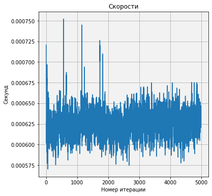

```python
s4 = np.array([])
for i in range(15,5000):
    start_time = time.time()
    Binetformula(i)
    end_time = (time.time() - start_time)
    s4=np.append(s4,end_time)

#Используем Savitzky–Golay filter
s4 = savgol_filter(s4,7,1)
drawPlot(s4)
```

Оуууууу..... А это нечто очень интересное. График не только стал линейным (+ -), но и угол между ядром графика и оси Х стал приближаться к 0.

```python
%time Binetformula(50000)
;
```

```
CPU times: user 775 µs, sys: 0 ns, total: 775 µs
Wall time: 782 µs
```

```
''
```

```python
%timeit Binetformula(50000)
;
```

```
63.1 µs ± 161 ns per loop (mean ± std. dev. of 7 runs, 10000 loops each)
```

```
''
```

Правда это учитывая, что мы получаем компактное число и не находим всю последовательность чисел.  
А если переводить число в полную форму?

```python
%%timeit
#Переводим в формат, чтоб каждая цифорка была :3

sp.Integer(Binetformula(50000))
;
```

```
68.8 µs ± 107 ns per loop (mean ± std. dev. of 7 runs, 10000 loops each)
```

Хм. Тест так же проведён на 10 000 повторов, но стало дольше лишь на 4-10 микросекунд 😲

Остался последний алгоритм. Матричный.

Но даже этот способ я смог поделить на два различных по скорости. Далее будет расписано

```python
#Здесь вручную происходит матричное возведение в степень

def __pow(x,n,I):
    if n==0:
        return I
    elif n==1:
        return x
    else:
        y = __pow(x,n//2,I)
        y = y.dot(y)
        if n%2:
            y = x.dot(y)
        return y

def MatrixFibonacci(index):
    F = __pow(np.array(((1,1),(1,0)),dtype=object),index,np.eye(2))
    return F[0][1]

MatrixFibonacci(50000)
;
```

```
''
```

```python
#А тут Numpy возведение в степень матрицы

def MatrixFibonacci2(index):
    return np.linalg.matrix_power(np.matrix(((1,1),(1,0)),dtype=object),index)[0,1]

MatrixFibonacci2(50000)
;
```

```
''
```

Сравним сразу два способа Numpy и ручной

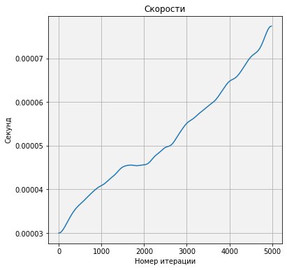

```python
# Ручной вариант

s5 = np.array([])
for i in range(15,5000):
    start_time = time.time()
    MatrixFibonacci(i)
    end_time = (time.time() - start_time)
    s5=np.append(s5,end_time)

s5 = gaussian_filter1d(s5,sigma=100)
drawPlot(s5)
```

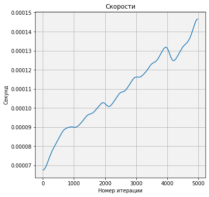

```python
# Numpy вариант

s6 = np.array([])
for i in range(15,5000):
    start_time = time.time()
    MatrixFibonacci2(i)
    end_time = (time.time() - start_time)
    s6=np.append(s6,end_time)

s6 = gaussian_filter1d(s6,sigma=100)
drawPlot(s6)
```

```python
%time MatrixFibonacci(50000)
;
%time MatrixFibonacci2(50000)
;
```

```
CPU times: user 2.26 ms, sys: 12 µs, total: 2.27 ms
Wall time: 2.1 ms
CPU times: user 2.37 ms, sys: 0 ns, total: 2.37 ms
Wall time: 2.38 ms
```

```
''
```

```python
%timeit MatrixFibonacci(50000)
;
%timeit MatrixFibonacci2(50000)
;
```

```
1.62 ms ± 2.58 µs per loop (mean ± std. dev. of 7 runs, 1000 loops each)
2.19 ms ± 6.37 µs per loop (mean ± std. dev. of 7 runs, 100 loops each)
```

```
''
```

Подведём итог

# Лучший алгоритм?

Можно теперь вызвать по отдельности:

```python
#RecursionFibonacci(30)             # 241 ms
#IterationFibonacci(30)             # 4 ms

#IterationFibonacci(500000)         # 2.79 s
#sp.Integer(Binetformula(500000))   # 366 ms
#MatrixFibonacci(500000)            # 252 ms
#MatrixFibonacci2(500000)           # 270 ms
```

А если посмотреть вот с такой стороны, то получается, что

Рекурсия - ужас.  
Итерация - так себе.  
Бине - Хорошо!  
Матрица - Замечательно!!

Однако, что надо заметить, Бине работает всё таки **гораздо быстрее** всех. Просто ему надо больше времени на сам вывод числа. А точнее, это надо именно моей функции.  
Если отказаться от sympy, то просто мы не сможем найти очень большие числа.

Что касаемо матричного способа - я на самом деле до сих пор не понимаю, почему numpy работает чуть медленее ручного возведения в степень. Возможно стоит пересмотреть алгоритм. Но разница у них совсем небольшая.

# А теперь создадим саму последовательность

### ...и посмотрим на график зависимости индекса от самого числа Фибоначчи

```python
#Найдём первые 1000 чисел Фибоначчи
FibonacciNumbers=set()
def findFibonacci():
    for i in range(1000):
        FibonacciNumbers.add(MatrixFibonacci(i))
findFibonacci()
```

```python
%timeit findFibonacci()

# Замер скорости
```

```
30.1 ms ± 70.3 µs per loop (mean ± std. dev. of 7 runs, 10 loops each)
```

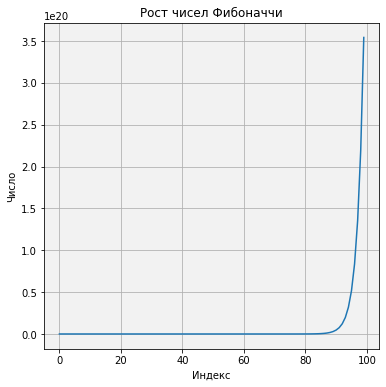

```python
#Первые 100 чисел Фибоначчи

drawPlot(sorted(list(FibonacciNumbers))[:100],"Рост чисел Фибоначчи","Число","Индекс")
```

```python
#Для быстрого результата посмотрим на первые 100 чисел

FibonacciNumbers2=set()
for i in range(100):
    FibonacciNumbers2.add(Binetformula(i))

#Ряд Фибоначчи по Бине
print(sorted(FibonacciNumbers2))

print("--------------------------------------------")

#Ряд Фибоначчи матричным методом
print(sorted((FibonacciNumbers)))
```

```
[0, 1.00000000000000, 2.00104225000000, 3.00208450000000, 5.00521233628506, 8.01042575885519, 13.0208547776977, 21.0396294028001, 34.0740551663899, 55.1356131229351, 89.2451819733222, 144.438260189035, 233.776457953269, 378.365258918985, 612.385370385555, 991.144980495649, 1604.16860953349, 2596.346…
--------------------------------------------
[0.0, 1, 2, 3, 5, 8, 13, 21, 34, 55, 89, 144, 233, 377, 610, 987, 1597, 2584, 4181, 6765, 10946, 17711, 28657, 46368, 75025, 121393, 196418, 317811, 514229, 832040, 1346269, 2178309, 3524578, 5702887, 9227465, 14930352, 24157817, 39088169, 63245986, 102334155, 165580141, 267914296, 433494437, 701408…
```

А давайте получим график в котором, посмотрим на дистанции между числами Фибоначчи? Что это значит?  
В зависимости от индекса мы узнаём сколько единиц до предыдущего числа Фибоначчи

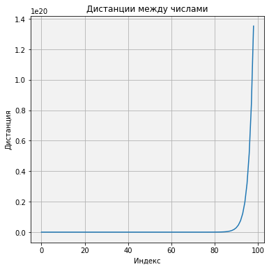

```python
FibonacciNumbersT=sorted(list(FibonacciNumbers))[:100]

#Просматривая список наших 100 чисел
Distances=[FibonacciNumbersT[i]-FibonacciNumbersT[i-1] for i in range(len(FibonacciNumbersT))][1:]
drawPlot(Distances,"Дистанции между числами","Дистанция","Индекс")
```

Оп! Да это же тот же самый график. Кстати и числа в списке такие же.  
Кроме того, что первое число $F_0 = 1$, хотя принято считать 0  
Однако, на некоторых статьях и форумах встречается вариант $ F_0=F_1=1 $ Вот вам и пояснение почему. Делая разницу между числами Фибоначчи, мы находим предыдущее предущего  
Но тут-то мы 0 не получаем, хотя изначально в ряде он есть. Поэтому $ F_0=0=1 $ без разницы.

### Плотность последовательности

Что такое плотность последовательности расписано в Википедии  
И я решил узнать как меняется плотность в ряде Фибоначчи в зависимости от роста индекса

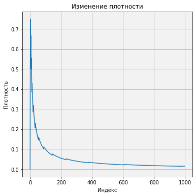

```python
#Ограничим последовательность до числа 1000
#Мы узнаем каковы плотности Фибоначчи до N-ого числа, где N - индекс текущего числа Фибоначчи

densities=[(len(list(filter(lambda x: x < i, sorted(FibonacciNumbers))))-1)/i for i in range(1,1000)]
drawPlot(densities,"Изменение плотности","Плотность","Индекс")
```

Это конечно очевидно, но мы видим КАК изменяется плотность в зависимости от роста числа Фибоначчи.  
По сути - это просто отношение плотности к индексу. А найдём скорость? То как быстро изменяется плотность в зависимости от индекса?

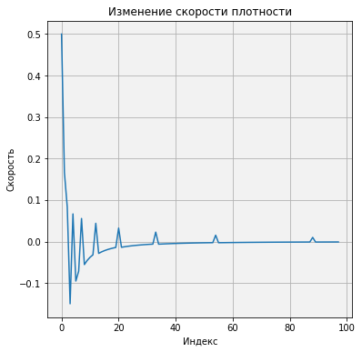

```python
adensities=[densities[i]-densities[i-1] for i in range(len(densities)-900)][1:]
drawPlot(adensities,"Изменение скорости плотности","Скорость","Индекс")
```

Правда сейчас я ограничился первыми 100 числами Фибоначчи, поскольку дальше идёт просто прямая как продолжение.

Что можно сказать? Как и ожидалось, есть конечно такие своего рода скачки, но в целом видно, что плотность уменьшается со временем => дистанция между числами увеличивается.

А теперь возникает вопрос...Если не вычитать числа Фибоначчи, а находить их отношения?  
Например следующие числа Фибоначчи ...3,5,8,13...

$ {{5}\over{3}}\approx{{8}\over{5}}\approx{{13}\over{8}} $

Выполняется ли равенство? Проверим на первых 20 числах!

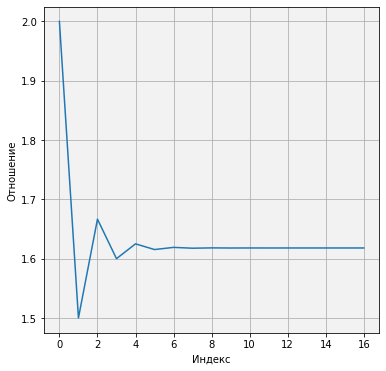

```python
lf=list(sorted(FibonacciNumbers))
ratioFibonacci=[lf[i]/lf[i-1] for i in range(2,len(sorted(FibonacciNumbers))-980)]
drawPlot(ratioFibonacci,"","Отношение","Индекс")
```

Ага! То есть равенство выполняется, однако начиная с 10-ого числа Фибоначчи!  
Хотя начиная с 6-ого числа начинается адекватная нормализация. Это значит, что ряд Фибоначчи сходится!  
И вот даже формула $ \lim_{n\to\infty} {{F_{n+1}}\over {F_n}} = \varphi $

Отношение чисел Фибоначчи - 1.618, если округлить. А это между прочим число **Золотого сечения**,  
О котором кстати у меня тоже будет в будущем статья.

Ну а что вы хотели? Иначе не могло быть, потому что именно благодаря этому соотношению и работает формула Бине,  
и именно поскольку Золотое сечение - иррациональное число, то и получаются погрешности в формуле Бине.

```python
df=pd.Series(sorted(FibonacciNumbers))

print("Среднее значение = ",df.mean())
print("Медиана",df.median())
```

```
Среднее значение =  7.040076847990272e+205
Медиана 1.3942322456169787e+104
```

Теперь предлагаю чуток статистики

Сколько чётных и нечётных чисел в последовательности Фибоначчи выборкой до 1000 ?

```
''
```

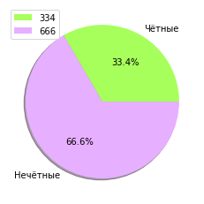

```python
EvenFibonacci=[int(i) for i in sorted(FibonacciNumbers) if int(i)%2==0]
plt.pie([len(EvenFibonacci),1000-len(EvenFibonacci)],
        colors=["#A7FF5B","#E7AFFF"],
        labels=["Чётные","Нечётные"],
        autopct='%1.1f%%',
        shadow=True,
        textprops={'color':"black"})
plt.legend([len(EvenFibonacci),1000-len(EvenFibonacci)])
;
```

Так-так-так...Чётных в первых 1000 числах Фибоначчи 334 штуки, а нечётных..666 😮😮😮😮😮

А вы не думали, что можно находить чётные числа по другому?  
Например, сейчас мы уже имеем все числа Фибоначчи на определенном интервале, и мы просто проверяем чётность уже позже.  
А почему бы не сгенерировать сразу только чётные числа Фибоначчи?  
А можно ли?  
Да!

Для начала сделаем так: представим нашу 100 чисел Фибоначчи в матрице, у которой размер строки будет например 5.

```python
df=pd.DataFrame(np.reshape(np.array(list(sorted(FibonacciNumbers))[:100]),(-1,5)))
df
```

|  | 0 | 1 | 2 | 3 | 4 |
| --- | --- | --- | --- | --- | --- |
| 0 | 0 | 1 | 2 | 3 | 5 |
| 1 | 8 | 13 | 21 | 34 | 55 |
| 2 | 89 | 144 | 233 | 377 | 610 |
| 3 | 987 | 1597 | 2584 | 4181 | 6765 |
| 4 | 10946 | 17711 | 28657 | 46368 | 75025 |
| 5 | 121393 | 196418 | 317811 | 514229 | 832040 |
| 6 | 1346269 | 2178309 | 3524578 | 5702887 | 9227465 |
| 7 | 14930352 | 24157817 | 39088169 | 63245986 | 102334155 |
| 8 | 165580141 | 267914296 | 433494437 | 701408733 | 1134903170 |
| 9 | 1836311903 | 2971215073 | 4807526976 | 7778742049 | 12586269025 |
| 10 | 20365011074 | 32951280099 | 53316291173 | 86267571272 | 139583862445 |
| 11 | 225851433717 | 365435296162 | 591286729879 | 956722026041 | 1548008755920 |
| 12 | 2504730781961 | 4052739537881 | 6557470319842 | 10610209857723 | 17167680177565 |
| 13 | 27777890035288 | 44945570212853 | 72723460248141 | 117669030460994 | 190392490709135 |
| 14 | 308061521170129 | 498454011879264 | 806515533049393 | 1304969544928657 | 2111485077978050 |
| 15 | 3416454622906707 | 5527939700884757 | 8944394323791464 | 14472334024676221 | 23416728348467685 |
| 16 | 37889062373143906 | 61305790721611591 | 99194853094755497 | 160500643816367088 | 259695496911122585 |
| 17 | 420196140727489673 | 679891637638612258 | 1100087778366101931 | 1779979416004714189 | 2880067194370816120 |
| 18 | 4660046610375530309 | 7540113804746346429 | 12200160415121876738 | 19740274219868223167 | 31940434634990099905 |
| 19 | 51680708854858323072 | 83621143489848422977 | 135301852344706746049 | 218922995834555169026 | 354224848179261915075 |

Теперь оставим только чётные числа

```python
df=pd.DataFrame(np.reshape(np.array(list(sorted(FibonacciNumbers))[:100]),(-1,5)))
df[df%2==0].fillna("")
```

|  | 0 | 1 | 2 | 3 | 4 |
| --- | --- | --- | --- | --- | --- |
| 0 | 0 |  | 2 |  |  |
| 1 | 8 |  |  | 34 |  |
| 2 |  | 144 |  |  | 610 |
| 3 |  |  | 2584 |  |  |
| 4 | 10946 |  |  | 46368 |  |
| 5 |  | 196418 |  |  | 832040 |
| 6 |  |  | 3524578 |  |  |
| 7 | 14930352 |  |  | 63245986 |  |
| 8 |  | 267914296 |  |  | 1134903170 |
| 9 |  |  | 4807526976 |  |  |
| 10 | 20365011074 |  |  | 86267571272 |  |
| 11 |  | 365435296162 |  |  | 1548008755920 |
| 12 |  |  | 6557470319842 |  |  |
| 13 | 27777890035288 |  |  | 117669030460994 |  |
| 14 |  | 498454011879264 |  |  | 2111485077978050 |
| 15 |  |  | 8944394323791464 |  |  |
| 16 | 37889062373143906 |  |  | 160500643816367088 |  |
| 17 |  | 679891637638612258 |  |  | 2880067194370816120 |
| 18 |  |  | 12200160415121876738 |  |  |
| 19 | 51680708854858323072 |  |  | 218922995834555169026 |  |

Круто, да?  
Тут есть чёткая закономерность.  
Хотя и так было понятно по прошлой диаграмме, что 334 (333 и ноль) из 1000 значит, что каждое третье число Фибоначчи - чётное!

Думаю, можно написать теперь матричный алгоритм для чётных чисел

```python
#Эта функция просто фильтрует.
#То есть выдаст ближайшее чётное число в
#зависимости от общего индекса среди чисел Фибоначчи.

def MatrixFibonacci2(index):
    if(index%3!=0):
        index+=1
        if((index)%3!=0):
            index+=1

    return np.linalg.matrix_power(np.matrix(((1,1),(1,0)),dtype=object),index)[0,1]

MatrixFibonacci2(6)
```

```
8
```

А можем генерировать по старинке, но заранее ограничиться условием про каждое третье число

```python
EvenFibonacciNumbers=[MatrixFibonacci(i) for i in range(1,1000) if i%3==0]
EvenFibonacciNumbers[:5]

#Первые пять чётных чисел
```

```
[2, 8, 34, 144, 610]
```

А теперь взглянем на **простоту** чисел. Кстати на эту тему я статью напишу нескоро, потому что простые числа, думаю, самое интересное и тяжелое, что есть в Теории Чисел.

Если кратко, простые числа - это числа, которые имеют только два делителя: 1 и само это же число  
Например: 5 можно поделить только на 1 и 5 => пятёрка - простое число.  
Остальные числа называются **составными**.

```
''
```

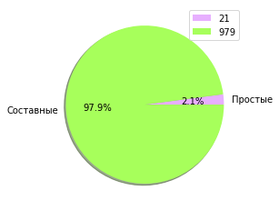

```python
PrimeFibonacci=[int(i) for i in sorted(FibonacciNumbers) if sp.isprime(i)]
plt.pie([len(PrimeFibonacci),1000-len(PrimeFibonacci)],
        colors=["#E7AFFF","#A7FF5B"],
        labels=["Простые","Составные"],
        autopct='%1.1f%%',
        shadow=True,
        textprops={'color':"black"})
plt.legend([len(PrimeFibonacci),1000-len(PrimeFibonacci)])
;
```

Оу...ну тоже ожидаемо. Ожидаемо, что простых много не будет.  
Только 21 число являются простыми в первой тысяче Фибоначчии.  
Это, как понятно, 2.1%

А сколько простых в 5000 Фибоначчи?

```
''
```

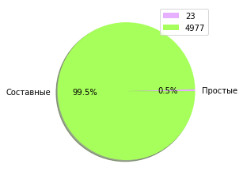

```python
PrimeFibonacci=[int(i) for i in sorted([MatrixFibonacci(j) for j in range(5000)]) if sp.isprime(i)]
plt.pie([len(PrimeFibonacci),5000-len(PrimeFibonacci)],
        colors=["#E7AFFF","#A7FF5B"],
        labels=["Простые","Составные"],
        autopct='%1.1f%%',
        shadow=True,
        textprops={'color':"black"})
plt.legend([len(PrimeFibonacci),5000-len(PrimeFibonacci)])
;
```

Ожидалась такая статистика в принципе, но так-то только два числа простых добавилось при новых 4000 Фибоначчи. Забавно.

Также, в будущем мы рассмотрим статью про **Совершенные числа**.  
Но попробуем уже их найти в числах Фибоначчи.  
Вкратце, совершенные числа - это числа, у которых сумма всех делителей кроме самого числа, равна этому же числу.

```python
#Находим все собственные делители

def Divisors(num):
    from math import sqrt as mmsq
    s=set([1])
    i=1
    a=int(mmsq(num)+1)
    while i<=a:
        if(num//i==num):
            i+=1
            continue
        if (num%i==0):
            if (num//i!=i):
                s.add(num//i)
            s.add(i)
        i+=1
    return s
```

```python
#Проверка на совершенство

def PerfectNumber(num):
    return sum(Divisors(num))==num
```

Также, давайте добавим случаи, когда сумма делителей больше и меньше числа.  
Такие числа называются **Избыточные** и **Недостаточные**

```python
#Избыточные
def AbundantNumber(num):
    return sum(Divisors(num))>num
```

Функцию делать для недосточных чисел здесь не надо, потому что это будут не избыточные, и не совершенные

Решил проверить первую 1000 Фибоначчи. Не дождался. Уже решил посмотреть на первые 100. Даже за 2 часа не обработало!  
Дело в том, что найти делители все для чисел больше, чем например $ 10^{35} $ довольно долго. Особенно это так, когда чисел больших очень много.  
Поэтому ограничимся первыми 70 числами Фибоначчи.

```
''
```

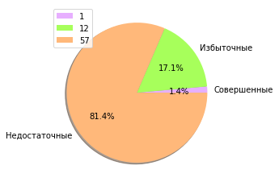

```python
fibs70=sorted(FibonacciNumbers)[:70]
PerfectFibonacci=[(i) for i in fibs70 if PerfectNumber(i)]
AbundantFibonacci=[(i) for i in fibs70 if AbundantNumber(i)]
piedata=[len(PerfectFibonacci),len(AbundantFibonacci),70-len(PerfectFibonacci)-len(AbundantFibonacci)]

plt.pie(piedata,
        colors=["#E7AFFF","#A7FF5B","#FFB87A"],
        labels=["Совершенные","Избыточные","Недостаточные"],
        autopct='%1.1f%%',
        shadow=True,
        textprops={'color':"black"})
plt.legend(piedata)
;

#Ушло 30 секунд!
```

И что мы видим? Только одно число в первых 70 попалось совершенным!  
Хотя совершенные числа и так не часто попадаются, но я убежден, что с ростом числа Фибоначчи Избыточных будет всё меньше и меньше.

А если встанет задача определить является ли число N числом Фибоначчи?  
Например, 34 - число Фибоначчи?

Мы не знаем...но можем узнать!

```python
def isFibonacci(num):
    from math import log as mlog
    a = 2.07684408521711*mlog(2.237*num)
    return (a % 1 * 100 > 90) or (a % 1 * 100 < 5)

isFibonacci(34)
```

```
True
```

Ну, выдало True, однако стоит посмотреть на алгоритм. Это обратная функция формулы Бине.  
Я конечно проверил много чисел на свойство Фибоначчи, но смею предположить, что на больших числах могут быть "обманы".

Хотя, вот пожалуйста. Оно думает, что и 33 - число Фибоначчи

```python
isFibonacci(33)
```

```
True
```

Если хорошо поизучать данную тему, можно найти ещё одну формулу для определения числа Фибоначчи $$ n={\log_\varphi{\left({{F_n\sqrt{5}+\sqrt{5F_n^2 \pm 4}}\over{2}}\right)}} $$

```python
def isFibonacci(num):
    from math import log as mlog
    a=mlog(( (num*5**(1/2)+(5*num**2 + 4)**(1/2))/2 ),1.618)
    b=mlog(( (num*5**(1/2)+(5*num**2 - 4)**(1/2))/2 ),1.618)
    a=(a+b)/2
    return (a % 1 * 100 > 99) or (a % 1 * 100 < 1)

isFibonacci(33),isFibonacci(34),isFibonacci(35),isFibonacci(143),isFibonacci(144)
```

```
(False, True, False, False, True)
```

Сразу проверил на нескольких числах новую функцию.  
Ну тут уже более менее лучше.  
Хотя ещё стоит проверять и дальше.

Возможно с ростом числа Фибоначчи нужно будет сжимать рамки для округления, которые вы можете увидеть на последней строчке функции, где return.  
Важно, чтоб левая часть стремилась к 99.999, а правая к нулю, однако мы не всегда можем гарантировать, что будет погрешность у числа Фибоначчи в большую сторону. Чем-то даже напоминает нейронные сети :3

## Слова Фибоначчи

С числами закончили :D

Переходим к словам Фибоначчи. Неожидали?  
У нас математика, а тут бац, и слова!

Но не всё так просто. Давайте разберём, что такое слова Фибоначчи.

> Слово Фибоначчи формируется путём повторения конкатенации тем же образом, что и числа Фибоначчи образуются путём повторяемых сложений.

То есть, если мы имеем изначально 0,1  
Следующее число Фибоначчи 0+1=1, получится ряд 0,1,1  
Снова прибавляем два последних, 1+1=2 и будет ряд 0,1,1,2  
Но мы только что пошли по "ветке", когда складываем числа при помощи арифметики.  
А нам же нужна конкатенация. Это когда мы "склеиваем" элементы

Например, имеем начальный ряд 0,1  
"Склеиваем" их..получаем 01; добавим в ряд и получим 0,1,01  
Но есть два НО.  
Во 1-ых, ряд слова Фибоначчи начинается с $ F_0=0 $ и $ F_1=01 $  
Во 2-ых, лучше записывать ряд без запятых (это же слово как никак)  
А если всё же и перечислять через запятую, то разделять число по цифрам, например 01 будет 0,1

А теперь напишем программу, которая будет находить нам N-ый элемент слова Фибоначчи, если мы подадим на вход индекс

```python
def IterationFibonacciWord(index):
    Sn_1 = "0"
    Sn = "01"
    tmp = ""
    for i in range(2, index + 1):
        tmp = Sn
        Sn += Sn_1
        Sn_1 = tmp
    return Sn

IterationFibonacciWord(1),IterationFibonacciWord(2)
```

```
('01', '010')
```

Сейчас мы создали итерационный метод. А есть ли **закрытая** форма нахождения элемента?  
Конечно, есть. Только тут мы находим скорей не элемент слова, а цифру.

```python
def FibonacciWord(index):
    from math import floor as mmmfloor
    return ((mmmfloor(index*1.618)-mmmfloor((index+1)*1.618))+2)


for i in range(30):
    print(FibonacciWord(i),end="")
```

```
101001010010010100101001001010
```

И всё же, если хотим получить "слово", то есть конкретно ряд, то проще сделать отдельную для этого функцию.

```python
def IterationFibonacciWords(indexLimit):
    Sn_1="0"
    Sn="01"
    tmp=""
    word=[Sn_1,Sn]
    for i in range(2, indexLimit + 1):
        tmp=Sn
        Sn+=Sn_1
        Sn_1=tmp
        word.append(Sn)
    return word
```

Посмотрим как визуально выстраивается данный ряд

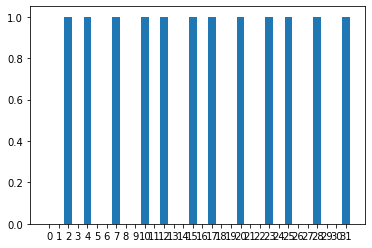

```python
myword1=list(map(int,"".join(IterationFibonacciWords(5))))
x = range(len(myword1))
ax = plt.gca()
ax.bar(x, myword1)
ax.set_xticks(x)
plt.show()
```

Не очень понятно зачем и как. Возникает вопрос, а есть ли что-то более понятное в визуализации такого ряда?  
Ответ: конечно есть!

У нас есть возможность рисовать фракталы! Достаточно "двигаться" вдоль ряда. Учтём правила:

1. Движемся вперёд
2. Если текущая цифра 0:  
   Повернуть налево, если номер движения чётный  
   Повернуть направо, если номер движения нечётный

```python
#Создаём картинку 600х600, и ставим курсор от куда будет рисовать чуть ниже центра

N=600
t = turtle.Turtle(fixed=False, width=N, height=N)
t.hideturtle()
t.penup()
t.back(N/2.2)
t.right(90)
t.forward(N/2.2)
t.left(90)
t.pendown()
t
```

```python
#Длина шага
step=2

j=0
k=0
while j<17:
    if(k==0):
        myword='0'
    else:
        myword=IterationFibonacciWord(j)
    for i in myword:
        t.forward(step)
        if(i=='0'):
            if((k)%2!=0):
                t.left(90)
            else:
                t.right(90)
        k+=1
    j+=1
    time.sleep(0.01)
```

[figure not shown]

И такой вот красивый узор у нас получается!  
Причём, он генерируется динамически  
Если заранее иметь датасет, то рисовать оно будет дольше из-за долгих распаковок

Кстати, а может ли рисовать фракталы ряд чисел Фибоначчи?  
Да, может, но это коснётся темы **золотого сечения** в одной из моих будущих статьей

# Конец

На этом всё, дорогие читатели!  
Надеюсь вам было интересно узнать что-то вроде такого из занимательной математики 😍

Ожидайте следующей статьи, в которой будут исследование чего-либо другого, например другой последовательности  
Если у вас есть мысли или пожелания, обязательно напишите...Может найду что подправить или добавить.

Здесь ссылка на датасеты чисел Фибоначчи [Числа Фибоначчи](https://github.com/lonagi/pysasha/tree/master/datasets/Number%20Theory/Fibonacci)

Почему я сказал датасеты? Если взять 100 000 чисел Фибоначчи в 1 файл, то у файла будет вес примерно в 1 ГБ.  
Я думаю, что лучше по частям (по чанкам) создавать такие .csv